# Missing Data practical Week 2

Kim Luijken, adapted from work by Valentijn de Jong and Thomas Debray

2022

This practical was developed using R version 4.1.1.

## Introduction

You perform a cohort study on annual influenza vaccine effectiveness. The aim of the study is to assess whether annual influenza vaccination reduces the risk of hospitalisation. The data consist of observations on eligible subjects who did, or did not, receive the annual influenza vaccine. The endpoint in this study is hospitalisation during the influenza epidemic period. Note that the vaccine was not randomly allocated; rather vaccination status may depend on characteristics of the participants in the study.

| Variable | Description | Coding | Meaning |
| --- | --- | --- | --- |
| vacc | Influenza vaccination | 0 | Unvaccinated |
| vacc | Influenza vaccination | 1 | Vaccinated |
| age | Age | Continuous | Years |
| sex | Sex | 0 | Male |
| sex | Sex | 1 | Female |
| cvd | Cardiovascular disease | 0 | Absent |
| cvd | Cardiovascular disease | 1 | Present |
| pulm | Pulmonary disease | 0 | Absent |
| pulm | Pulmonary disease | 1 | Present |
| DM | Diabetus mellitus | 0 | Absent |
| DM | Diabetus mellitus | 1 | Present |
| contact | Number of GP contacts | Discrete | Count |
| hosp | Hospitalisation status | 0 | No hospitalisation |
| hosp | Hospitalisation status | 1 | Hospitalisation |

## Aim of the practical

In this practical you will be given a data set without any missings and a data set with missings to compare the differences.  
The aims of the current practical are:

- to get familiar with approaches to describe missingness patterns
- to observe the difference in results between a complete case analysis and analysis of the complete data (that is not available in practice)

## Preparation

The research question you will address during the practicals over these three weeks is whether influenza vaccination affects hospitalisation. As vaccination was not randomized, confounder adjustment is necessary. To investigate the effect of influenza vaccination on risk of hospitalisation, we will fit the following regression model:

```r
formula(hosp ~ vacc + DM + cvd + pulm + I(log(contact)) + age + sex)
```

### Describing missingness

First, load the data with missing observations.

```r
load("miss.data.multi.RData") # if the data is in your working directory
load(file.choose()) # if it is not
```

**Question 1.** How many observations do we have? What percentage of observations is missing, on each variable?

```r
summary(miss.data.multi)
```

```
##       vacc            age              sex              cvd
##  Min.   :0.000   Min.   : 65.00   Min.   :0.0000   Min.   :0.00
##  1st Qu.:0.000   1st Qu.: 70.00   1st Qu.:0.0000   1st Qu.:0.00
##  Median :1.000   Median : 75.00   Median :1.0000   Median :0.00
##  Mean   :0.737   Mean   : 75.65   Mean   :0.6191   Mean   :0.47
##  3rd Qu.:1.000   3rd Qu.: 80.00   3rd Qu.:1.0000   3rd Qu.:1.00
##  Max.   :1.000   Max.   :104.00   Max.   :1.0000   Max.   :1.00
##  NA's   :5263                                      NA's   :10413
##       pulm             DM           contact            hosp
##  Min.   :0.000   Min.   :0.000   Min.   :  2.00   Min.   :0.0000
##  1st Qu.:0.000   1st Qu.:0.000   1st Qu.:  6.00   1st Qu.:0.0000
##  Median :0.000   Median :0.000   Median : 12.00   Median :0.0000
##  Mean   :0.123   Mean   :0.064   Mean   : 14.57   Mean   :0.0061
##  3rd Qu.:0.000   3rd Qu.:0.000   3rd Qu.: 19.00   3rd Qu.:0.0000
##  Max.   :1.000   Max.   :1.000   Max.   :146.00   Max.   :1.0000
##  NA's   :6600    NA's   :5277    NA's   :3966     NA's   :1346
```

```r
str(miss.data.multi)
```

```
## 'data.frame':    40000 obs. of  8 variables:
##  $ vacc   : int  1 1 1 NA 1 1 1 1 1 NA ...
##  $ age    : int  66 73 75 76 77 78 80 81 66 67 ...
##  $ sex    : int  0 1 1 1 1 1 1 1 0 0 ...
##  $ cvd    : int  0 1 1 NA 1 1 NA 1 NA 0 ...
##  $ pulm   : int  1 0 0 NA 0 0 0 0 0 NA ...
##  $ DM     : int  0 0 0 NA 0 0 0 0 0 0 ...
##  $ contact: int  27 4 8 NA 7 5 9 17 10 NA ...
##  $ hosp   : int  0 0 0 NA 0 0 0 0 0 0 ...
```

```r
pct.missing <- round(colMeans(is.na(miss.data.multi)) * 100, 2)
pct.missing
```

```
##    vacc     age     sex     cvd    pulm      DM contact    hosp
##   13.16    0.00    0.00   26.03   16.50   13.19    9.92    3.36
```

```r
miss.cvd <- is.na(miss.data.multi$cvd) # Indicators of missing information on cvd.
```

*Answer: We have a total of 40000 observations. The missingness on the variables varies from 0% to 26.03%. On average, 10.27% is missing.*

For describing the missing data pattern, we recommend using the ggmice package. Further reading on use of the ggmice package (particularly as a tool during imputation) can be found on: https://cran.r-project.org/web/packages/ggmice/vignettes/ggmice.html

First, install and load the ggmice package

```r
install.packages("devtools")
devtools::install_github("amices/ggmice")
library(ggmice)
```

The `plot_pattern()` function displays the missing data pattern in an incomplete data set. Hence, you can see what variables have missing observations and in which comination of variables missingness occurs. Although assumptions about missing data mechanisms are typically made based on background knowledge of the data generating mechanims, observing missingness patterns in the data helps further understanding the reasons for missingness.

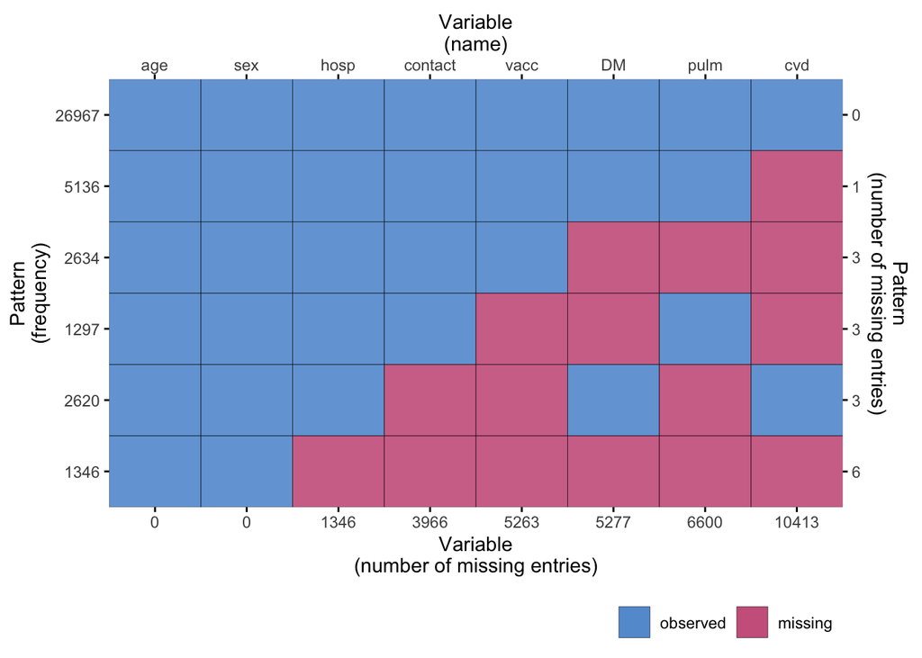

```r
plot_pattern(miss.data.multi)
```

Interpret the plot.

**Question 2.** Which data pattern occurs most often?

*Answer: Fully observed data. All variables were observed in 26967 individuals*

**Question 3.** Have a look at the second missingness pattern. Information on Diabetes Mellitus, pulmonary disease and cardiovascular disease was often missing in all three variables (in 2634 occurrences). What might have been a reason for this?

*Answer: These variables represent the three co-morbidities measured in this data. If information on co-moribidities was not registered for an individual, all three variables have a common missing observation.*

**Question 4.** Do you think the missingness was caused by a MAR or MNAR mechanism? Why?

*Answer: There is no statistical test that can indicate whether data ar MAR of MNAR. The assumption of MAR of MNAR needs to be made by you as a researcher.*

### Analysing the complete data set

This part of the practical is an analysis that we can never do in practice, but is insightful for comparisons. We will analyze the original data set without any missing values.

Load the data.

```r
load("full.data.RData") # if the data is in your working directory
load(file.choose()) # if it is not
```

Perform the analysis of interest.

```r
nomissing_model <- glm( hosp ~ vacc + DM + cvd + pulm + I(log(contact)) + age + sex,
                        data = FULL.data,
                        family = binomial())

summary( nomissing_model)
```

```
##
## Call:
## glm(formula = hosp ~ vacc + DM + cvd + pulm + I(log(contact)) +
##     age + sex, family = binomial(), data = FULL.data)
##
## Deviance Residuals:
##     Min       1Q   Median       3Q      Max
## -0.5537  -0.1253  -0.0919  -0.0679   3.7124
##
## Coefficients:
##                   Estimate Std. Error z value Pr(>|z|)
## (Intercept)     -11.293100   0.678570 -16.643  < 2e-16 ***
## vacc             -0.434732   0.144848  -3.001 0.002688 **
## DM                0.398712   0.203533   1.959 0.050118 .
## cvd               0.608454   0.150048   4.055 5.01e-05 ***
## pulm              0.529845   0.157398   3.366 0.000762 ***
## I(log(contact))   0.403380   0.099686   4.047 5.20e-05 ***
## age               0.069918   0.008598   8.132 4.24e-16 ***
## sex              -0.755138   0.130411  -5.790 7.02e-09 ***
## ---
## Signif. codes:  0 '***' 0.001 '**' 0.01 '*' 0.05 '.' 0.1 ' ' 1
##
## (Dispersion parameter for binomial family taken to be 1)
##
##     Null deviance: 3076.5  on 39999  degrees of freedom
## Residual deviance: 2881.4  on 39992  degrees of freedom
## AIC: 2897.4
##
## Number of Fisher Scoring iterations: 8
```

### Complete case analysis (CCA)

Fit the prespecified model. Complete case analysis is the default option in `glm()` (as is common in statistical software), so we can easily fit it as follows:

```r
cca_model <- glm( hosp ~ vacc + DM + cvd + pulm + I(log(contact)) + age + sex,
                  data = miss.data.multi,
                  family = binomial())

summary( cca_model)
```

```
##
## Call:
## glm(formula = hosp ~ vacc + DM + cvd + pulm + I(log(contact)) +
##     age + sex, family = binomial(), data = miss.data.multi)
##
## Deviance Residuals:
##     Min       1Q   Median       3Q      Max
## -0.1631  -0.0472  -0.0342  -0.0249   3.9701
##
## Coefficients:
##                  Estimate Std. Error z value Pr(>|z|)
## (Intercept)     -12.03738    2.28412  -5.270 1.36e-07 ***
## vacc             -0.58498    0.45047  -1.299   0.1941
## DM               -0.21044    1.03374  -0.204   0.8387
## cvd               1.01574    0.50795   2.000   0.0455 *
## pulm              0.42499    0.57463   0.740   0.4595
## I(log(contact))   0.29634    0.32441   0.913   0.3610
## age               0.05650    0.02944   1.919   0.0550 .
## sex              -0.63200    0.43116  -1.466   0.1427
## ---
## Signif. codes:  0 '***' 0.001 '**' 0.01 '*' 0.05 '.' 0.1 ' ' 1
##
## (Dispersion parameter for binomial family taken to be 1)
##
##     Null deviance: 371.06  on 26966  degrees of freedom
## Residual deviance: 355.12  on 26959  degrees of freedom
##   (13033 observations deleted due to missingness)
## AIC: 371.12
##
## Number of Fisher Scoring iterations: 10
```

**Question 5.** Does this method use all information in the data set? Hint: check the degrees of freedom and consider the number of estimated parameters in the regression model.

*Answer: No. The number of residual degrees of freedom is 26959 and 8 parameters were estimated. Therefore, 26967 patients were used in this model development, meaning that 32.58% of the data was discarded, even though on average only 10.27% was missing.*

**Question 6.** How did the complete case analysis affect study findings?

*Answer: In this scenario, the exclusion of individuals with any missing value resulted in a found OR between influenza vacination and risk of hospitalization of 0.56 compared to an OR of 0.65 in the analysis of data without any missings (not available in practice).*